# `FGCluster` updates

2020/03/05 Giuseppe, Josquin, Davide

1. Uncertainties on spectral parameters from realistic simulations with Multigrid approach, 1000 simulations from Josquin (2 weeks presentation ), obtained as the std dev estimated on each pixel across the 1000 maps.
2. Derive new clusters with these uncertainties
3. Minimize a new partition
   - for K in range(Kmin, Kmax)
   - estimate K clusters given the map of uncertaintes
   - get stat. and sys power spectra residuals given K patches
   - estimate variance as $$ \sigma _X =\sum_{\ell} (2\ell +1)C_{\ell, X}^{BB}\quad with \quad X=sys, stat $$ The more the clusters, the higher Stat. residuals ( increases with K, overpartition ). the more the clusters, the lower Sys. residuals (decreases with K underpartition)
4. Optimal K : where $\sigma_{tot} = \sqrt{\sigma_{stat} ^2+ \sigma_{sys} ^2 }$ is minimum
5. Josquin implemented a new component separation routine which essentially can get as input patches estimated singularly for each spectral parameter, (no need anymore of pairing clusters etc... ), under testing phase.

Therefore so far, I modified the sky configuration parameters so that we have just Bd varying and kept both Td and Bs constant .

```python
from IPython.display import HTML

HTML('''<script>
code_show=true;
function code_toggle() {
 if (code_show){
 $('div.input').hide();
 } else {
 $('div.input').show();
 }
 code_show = !code_show
}
$( document ).ready(code_toggle);
</script>
<form action="javascript:code_toggle()"><input type="submit" value="Click here to toggle on/off the raw code."></form>''')
```

```python
%load_ext autoreload
%autoreload 2
%matplotlib inline

import healpy as hp
import pysm
import pylab as pl
from fgbuster.observation_helpers import get_instrument, get_sky
from fgbuster.component_model import CMB, Dust, Synchrotron
from fgbuster.visualization import corner_norm

from fgbuster.separation_recipies import basic_comp_sep,adaptive_weighted_comp_sep
#from fgbuster.xForecast import _get_Cl_cmb, _get_Cl_noise
from fgbuster.mixingmatrix import MixingMatrix
import multiprocessing as mp
from functools import partial
from fgbuster.algebra import W_dB, _mmm
import sys
from pysm.common import bandpass_convert_units, K_RJ2Jysr, K_CMB2Jysr, convert_units
import os
from pylab import cm
cmap = cm.get_cmap('RdYlBu')
cmap.set_under('w')
cmap2 = cm.get_cmap('tab20b')
cmap2.set_under('w')

from clustering_utils import ClusterData
from fgcluster import estimate_Stat_and_Sys_residuals, estimate_spectra
import warnings
warnings.filterwarnings("ignore")
```

```
The autoreload extension is already loaded. To reload it, use:
  %reload_ext autoreload
```

```python
nside =32
skyconf=get_sky(nside, 'd1s1')

bdpysm =skyconf['dust'][0]['spectral_index']
Tdpysm =skyconf['dust'][0]['temp']
bspysm  =skyconf['synchrotron'][0]['spectral_index']
Galmask=hp.read_map(f'/Users/peppe/work/heavy_maps/HFI_Mask_GalPlane-apo2_{nside}_R2.00.fits', verbose=False )
Galmask  =  pl.ma.masked_not_equal(Galmask,0 ).mask
```

```python
ebdpysm = hp.read_map('sigmaBd_multigrid.fits', verbose=False)*Galmask
ebspysm = hp.read_map('sigmaBs_multigrid.fits', verbose=False )
eTdpysm = hp.read_map('sigmaTd_multigrid.fits', verbose = False )
bdpysm[~Galmask]=0
#Tdpysm[~Galmask]= 0
ebdpysm [~Galmask ] =hp.UNSEEN
#eTdpysm [~Galmask ] =hp.UNSEEN
```

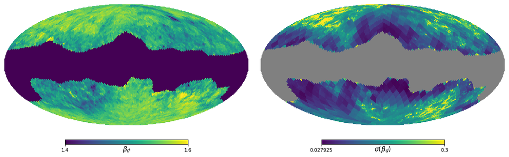

```python
pl.figure(figsize=(15,8) )
hp.mollview(ebdpysm , sub=122 ,title='',  unit=r'$\sigma(\beta_d) $' , max=.3)
hp.mollview( bdpysm , title='', unit=r'$\beta_d$', min=1.4, max=1.6
            , sub=121 )
```

**Fig1**

```python
skyconf['dust'][0]['temp']=20
skyconf['synchrotron'][0]['spectral_index']=-3
instrumentconf= get_instrument('litebird', nside)
```

```python
from sklearn import preprocessing
angles=False
affinity ='hellinger'
save_affinity = True

if angles :
    file_affinity = f'/Users/peppe/work/adaptive_compsep/affinities/{affinity}_haversine_{nside}.npy'
else:
    file_affinity = f'/Users/peppe/work/adaptive_compsep/affinities/{affinity}_{nside}.npy'

file_affinity= f'/Users/peppe/work/adaptive_compsep/affinities/{affinity}_Bd_{nside}_multigrid_w0p6.npy'
Cluster   =ClusterData([bdpysm, ebdpysm ]    ,  nfeatures=2,
                          nside=nside,  affinity=affinity  ,file_affinity =file_affinity ,
                          include_haversine=angles, verbose=True ,save_affinity=save_affinity ,
                       scaler=None, #preprocessing.StandardScaler() ,
                       feature_weights=[1, .6 ]  )
```

```python
Cluster(nvals=15  , Kmax=100 , minimize='residuals',  sky_conf=skyconf , instrument_conf=instrumentconf,
        galactic_binmask =Galmask )
```

[output not shown]

[output cut: 503 more lines]

```
0068.40 | 08.01 | 11.30 | 00.00
0078.00 | 07.30 | 10.30 | 00.00
0088.50 | 05.96 | 08.40 | 00.00
0100.00 | 04.96 | 07.00 | 00.00
0118.90 | 04.11 | 05.80 | 00.00
0140.00 | 03.33 | 04.70 | 00.00
0166.00 | 04.96 | 07.00 | 00.00
0195.00 | 04.11 | 05.80 | 00.00
0234.90 | 05.67 | 08.00 | 00.00
0280.00 | 06.45 | 09.10 | 00.00
0337.40 | 08.09 | 11.40 | 00.00
0402.10 | 13.90 | 19.60 | 00.00
Instrument attribute 'pixel_indices' not set.
(15, 1)
Optimal number of clusters: K_opt =44
```

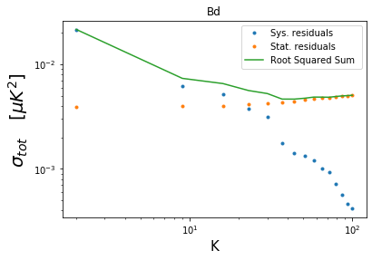

```python
pl.title('Bd')
pl.plot(Cluster.Kvals, Cluster.Vu,'.',label=r'Sys. residuals' )
pl.plot(Cluster.Kvals, Cluster.Vo ,'.',label=r'Stat. residuals ')
pl.plot(Cluster.Kvals, pl.sqrt(Cluster.Vo**2 +Cluster.Vu**2) ,'-', label=r'Root Squared Sum ')
pl.loglog()
pl.xlabel('K',fontsize=15)
pl.ylabel(r'$\sigma_{tot} \quad [ \mu K^2 ]$ ',fontsize=20  )
pl.legend()
```

**Fig2** Total Variances as a function of number of clusters

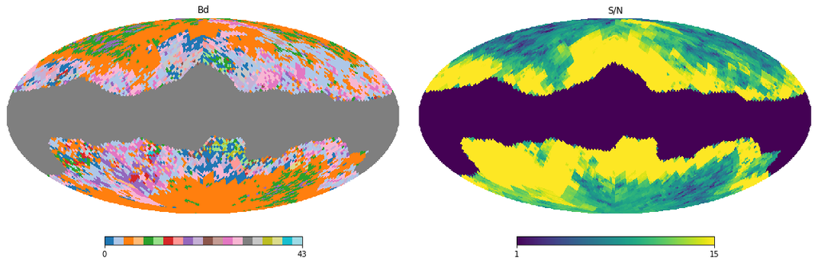

```python
pl.figure(figsize=(15,8))
hp.mollview(Cluster.clusters.labels_ , title='Bd' , cmap=pl.cm.tab20, sub=121   )
hp.mollview(bdpysm/(  ebdpysm), min=1  ,sub=122 , max=15, title='S/N' )


idpatches = Cluster.clusters.labels_
```

[output not shown]

[output cut: 204 more lines]

[output not shown]

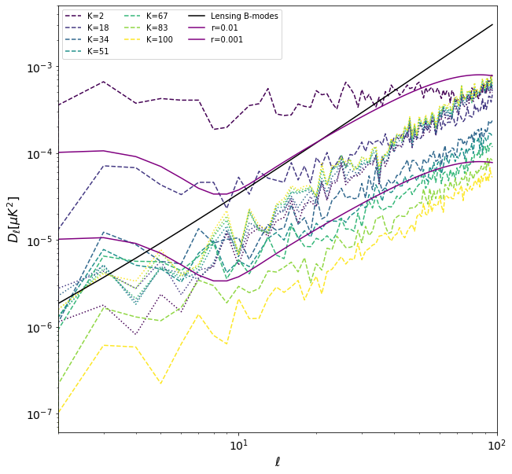

```python
nvals = 7
colors = pl.cm.viridis(pl.linspace(0,1,nvals ))
pl.figure(figsize=(10,10))
for i,K in pl.ndenumerate(pl.linspace(2,100, num=nvals, dtype=pl.int_)):
    Cluster(K)
    idpatches =Cluster.clusters.labels_
    msys,mstat = estimate_Stat_and_Sys_residuals( idpatches, skyconf , instrumentconf,Galmask  )
    clsys,clstat,varsys,varstat  =estimate_spectra (msys, mstat )
    ell=pl.arange(  clsys.shape[1]   )
    pl.loglog(ell, ell*( ell +1)/2./pl.pi* clsys[2, :],  '--', label = f'K={K}', color=colors[i[0]])

    pl.loglog(ell, ell*( ell +1)/2./pl.pi* clstat[2, :], ':',   color=colors[i[0]])
    #break

clr = pl.loadtxt('/Users/peppe/work/satellite_sims/power_spectra/Class_planck2015_r0_cl_lensed.dat')
clr1 = pl.loadtxt('/Users/peppe/work/satellite_sims/power_spectra/Class_planck2015_r1_cl_unlensed.dat')
pl.loglog(ell, clr[ :ell.shape[0],3]*ell*( ell +1)/2./pl.pi   ,'k',label='Lensing B-modes'  )
pl.loglog(ell, clr1[ :ell.shape[0],3]*ell*( ell +1)/2./pl.pi /100.  ,'-',color='purple', label='r=0.01'  )
pl.loglog(ell, clr1[ :ell.shape[0],3]*ell*( ell +1)/2./pl.pi /1000.  ,color='purple',label='r=0.001 '  )

pl.xlim(2, 100)
pl.ylabel(r'$D_{\ell}  [ \mu K^2 ]$', fontsize=16)
pl.xlabel(r'$ {\ell}   $', fontsize=16)
pl.yticks(fontsize=14)
pl.xticks(fontsize=14)

pl.legend(loc='best', ncol=3)
```

**Fig4** (dashed ) Systematic and (dotted ) Statistical residuals for different values of K.

```python
sky = pysm.Sky(skyconf)
instrument = pysm.Instrument(instrumentconf )
freq_maps, noise  = instrument.observe(sky, write_outputs=False, )

freq_mapn = freq_maps + noise
```

```
nu (GHz) | sigma_I (uK_CMB amin) | sigma_P (uK_CMB amin) | FWHM (arcmin)

0040.00 | 25.60 | 36.10 | 00.00
0050.00 | 13.90 | 19.60 | 00.00
0060.00 | 14.33 | 20.20 | 00.00
0068.40 | 08.01 | 11.30 | 00.00
0078.00 | 07.30 | 10.30 | 00.00
0088.50 | 05.96 | 08.40 | 00.00
0100.00 | 04.96 | 07.00 | 00.00
0118.90 | 04.11 | 05.80 | 00.00
0140.00 | 03.33 | 04.70 | 00.00
0166.00 | 04.96 | 07.00 | 00.00
0195.00 | 04.11 | 05.80 | 00.00
0234.90 | 05.67 | 08.00 | 00.00
0280.00 | 06.45 | 09.10 | 00.00
0337.40 | 08.09 | 11.40 | 00.00
0402.10 | 13.90 | 19.60 | 00.00
Instrument attribute 'pixel_indices' not set.
```

```python
freq_mapn[:,:,~Galmask] =hp.UNSEEN
freq_maps[:,:,~Galmask] =hp.UNSEEN
cov =pl.ones_like(freq_maps)
for i in range(freq_maps.shape[0]):
    cov[i,0,:]*=(instrument.Sens_I[i] )**2/hp.nside2resol(nside, arcmin=True)
    cov[i,1,:]*=(instrument.Sens_P[i] )**2/hp.nside2resol(nside, arcmin=True)
cov[:,2,:]= cov[:,1,:]
components = [CMB(), Synchrotron(20), Dust(353) ]
```

```python
result   = adaptive_weighted_comp_sep(components, instrument, freq_maps[:,1:] ,cov[:,1:] ,
                                       idpatches)

resultconst   = basic_comp_sep(components, instrument, freq_maps[:,1:] )
```

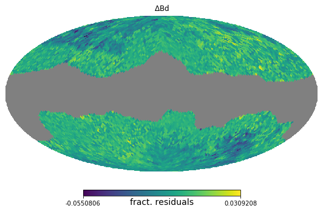

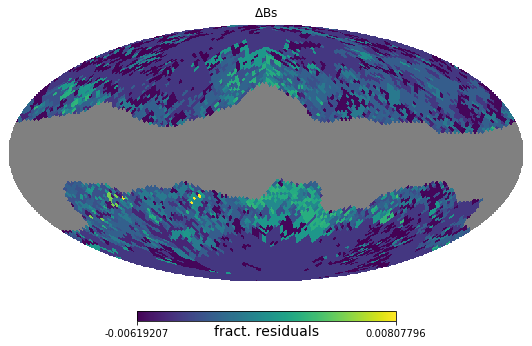

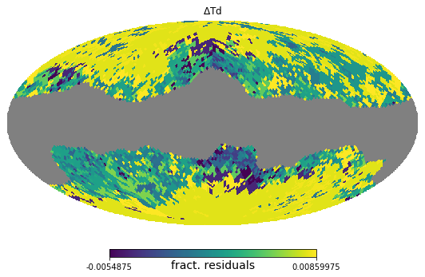

```python
pl.figure(figsize=(15,8))
diff = (result.x[1][idpatches] - bdpysm )/bdpysm
diff[~Galmask]=hp.UNSEEN
hp.mollview(diff
            ,sub=121, title =r'$\Delta $Bd'  , unit='fract. residuals'  )
pl.figure(figsize=(15,8))

diff = (result.x[0][idpatches] -(-3) )/(-3)
diff[~Galmask]=hp.UNSEEN
hp.mollview(diff
            ,sub=121, title =r'$\Delta $Bs'  , unit='fract. residuals'  )
pl.figure(figsize=(15,8))

diff = (result.x[2][idpatches] -(20) )/(20)
diff[~Galmask]=hp.UNSEEN
hp.mollview(diff
            ,sub=121, title =r'$\Delta $Td'  , unit='fract. residuals'  )
```

**Fig.5** Fractional residuals from the spectral parameters estimated in each patch

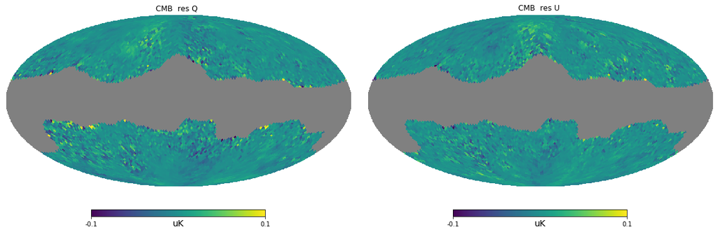

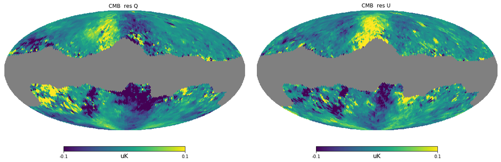

```python
pl.figure(figsize=(16,10 ))

hp.mollview(result.s[0,0] , title='CMB  res Q ', sub=(121), min=-0.1,max=0.1, unit='uK')
hp.mollview(result.s[0,1] , title='CMB  res U ', sub=(122), min=-0.1,max=0.1, unit='uK')


_=pl.figure(figsize=(16,10 ))
hp.mollview(resultconst.s[0,0] , title='CMB  res Q ', sub=(121), min=-0.1,max=0.1, unit='uK')
hp.mollview(resultconst.s[0,1] , title='CMB  res U ', sub=(122), min=-0.1,max=0.1, unit='uK')
```

**Fig.6**(top) CMB residuals with adaptive comp sep ,(bottom) by assuming constant spectral index .

```python
m = pl.zeros_like (freq_maps[0])
mconst = pl.zeros_like (freq_maps[0] )
for i in range(2):
    m[i+1,:] = result.s[0,i]
    mconst[i+1,:] = resultconst .s[0,i]
clconst = hp.anafast(   mconst    ,lmax=3*nside  )
cl = hp.anafast(m   ,lmax=3*nside  )
ell=pl.arange(  cl.shape[1]   )
```

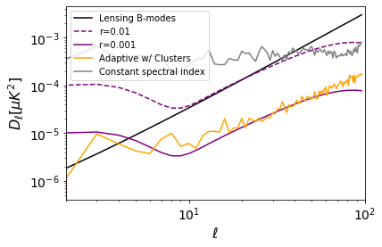

```python
clr = pl.loadtxt('/Users/peppe/work/satellite_sims/power_spectra/Class_planck2015_r0_cl_lensed.dat')
clr1 = pl.loadtxt('/Users/peppe/work/satellite_sims/power_spectra/Class_planck2015_r1_cl_unlensed.dat')
pl.loglog(ell, clr[ :ell.shape[0],3]*ell*( ell +1)/2./pl.pi   ,'k',label='Lensing B-modes'  )
pl.loglog(ell, clr1[ :ell.shape[0],3]*ell*( ell +1)/2./pl.pi /100.  ,'--',color='purple', label='r=0.01'  )
pl.loglog(ell, clr1[ :ell.shape[0],3]*ell*( ell +1)/2./pl.pi /1000.  ,color='purple',label='r=0.001 '  )
pl.loglog(ell, ell*( ell +1)/2./pl.pi* cl[2, :], color='orange', label = 'Adaptive w/ Clusters')

pl.loglog(ell, ell*( ell +1)/2./pl.pi* clconst[2, :], color='grey',  label='Constant spectral index')
pl.xlim(2, 100)
pl.ylabel(r'$D_{\ell}  [ \mu K^2 ]$', fontsize=16)
pl.xlabel(r'$ {\ell}   $', fontsize=16)
pl.yticks(fontsize=14)
pl.xticks(fontsize=14)

pl.legend()
#pl.ylim(1e-7, 1e-2)
```

**Fig.7** Power spectra of CMB residuals.

# Summary

- Improvements on the overall post-compsep residuals are very promising
- Try Josquin new routine,and run with `d1s1`
- optimal number of clusters criterion now is driven from a more physical argument. Ideally we may want that the optimal K is the one fullfilling the requirements, (in progress )

## Backup

```python
NMC = 25
arrcl=pl.zeros((NMC, 3*nside +1 ) )
compute_const=True

lbconf = get_instrument('litebird', nside )
lbconf ['add_noise'] =True
if compute_const :
    arrclconst=pl.zeros_like(arrcl)
for mc in range( NMC  ) :
    lbconf ['noise_seed'] =mc +123429304
    instrument = pysm.Instrument(lbconf)
    freq_map, noise  = instrument.observe(sky, write_outputs=False )
    freq_mapn     = freq_map + noise
    freq_mapn[:,:,~Galmask] =hp.UNSEEN
    freqs=  pl.array(instrument.Frequencies)
    print(mc )
    cov =pl.ones_like(freq_mapn)
    for i in range(freqs.shape[0]):
        cov[i,0,:]*=(instrument.Sens_I[i] )**2/hp.nside2resol(nside, arcmin=True)
        cov[i,1,:]*=(instrument.Sens_P[i] )**2/hp.nside2resol(nside, arcmin=True)
    cov[:,2,:]= cov[:,1,:]

    result   = adaptive_weighted_comp_sep(components, instrument, freq_mapn[:,1:] ,cov[:,1:] ,
                                           idpatches)

    m = pl.zeros_like (freq_mapn[0])
    for i in range(2):
        m[i+1,:] = result.s[0,i]
        nan = pl.ma.masked_invalid ( result.s[0,i] ) .mask
        m[i+1,nan] = hp.UNSEEN
    cl = hp.anafast(m   ,lmax=3*nside  )
    arrcl [ mc,: ]= cl[2,:]
    if compute_const :
        resultconst   = basic_comp_sep(components, instrument, freq_mapn[:,1:] )
        mconst = pl.zeros_like (freq_mapn[0] )

        for i in range(2):

            mconst[i+1,:] = resultconst .s[0,i]
        clconst = hp.anafast(   mconst    ,lmax=3*nside  )
        arrclconst [mc,: ] = clconst  [2, : ]
```

[output not shown]

[output cut: 420 more lines]

[output not shown]

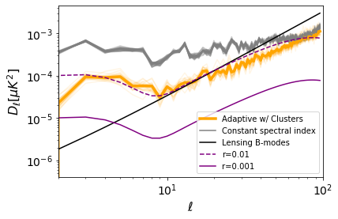

```python
clr = pl.loadtxt('/Users/peppe/work/satellite_sims/power_spectra/Class_planck2015_r0_cl_lensed.dat')
clr1 = pl.loadtxt('/Users/peppe/work/satellite_sims/power_spectra/Class_planck2015_r1_cl_unlensed.dat')
ell=pl.arange(  cl.shape[1]   )
for mc in range(NMC) :
    pl.loglog(ell, ell*( ell +1)/2./pl.pi* arrcl[mc, :],color='orange', alpha=.1 )

    if compute_const : pl.loglog(ell, ell*( ell +1)/2./pl.pi* arrclconst[mc , :], color='grey',   alpha=.4 )
pl.loglog(ell, ell*( ell +1)/2./pl.pi* arrcl.mean(axis=0) ,color='orange' , lw=3.5,  label = 'Adaptive w/ Clusters')
if compute_const:
    pl.loglog(ell, ell*( ell +1)/2./pl.pi* arrclconst.mean(axis=0) , color='grey',  label='Constant spectral index',             )

pl.loglog(ell, clr[ :ell.shape[0],3]*ell*( ell +1)/2./pl.pi   ,'k',label='Lensing B-modes'  )
pl.loglog(ell, clr1[ :ell.shape[0],3]*ell*( ell +1)/2./pl.pi /100.  ,'--',color='purple', label='r=0.01'  )
pl.loglog(ell, clr1[ :ell.shape[0],3]*ell*( ell +1)/2./pl.pi /1000.  ,color='purple',label='r=0.001 '  )
pl.xlim(2, 100)
pl.ylabel(r'$D_{\ell}  [ \mu K^2 ]$', fontsize=16)
pl.xlabel(r'$ {\ell}   $', fontsize=16)
pl.yticks(fontsize=14)
pl.xticks(fontsize=14)

pl.legend()
```

```python
sky = pysm.Sky(get_sky(nside, 'd0s0' ))
instrument = pysm.Instrument(get_instrument('litebird', nside))
freq_maps, noise  = instrument.observe(sky, write_outputs=False, )

freq_mapn = freq_maps + noise
freq_mapn[:,:,~Galmask] =hp.UNSEEN
freq_maps[:,:,~Galmask] =hp.UNSEEN
cov =pl.ones_like(freq_maps)
for i in range(freq_maps.shape[0]):
    cov[i,0,:]*=(instrument.Sens_I[i] )**2/hp.nside2resol(nside, arcmin=True)
    cov[i,1,:]*=(instrument.Sens_P[i] )**2/hp.nside2resol(nside, arcmin=True)
cov[:,2,:]= cov[:,1,:]
components = [CMB(), Synchrotron(20), Dust(353) ]
```

```
nu (GHz) | sigma_I (uK_CMB amin) | sigma_P (uK_CMB amin) | FWHM (arcmin)

0040.00 | 25.60 | 36.10 | 00.00
0050.00 | 13.90 | 19.60 | 00.00
0060.00 | 14.33 | 20.20 | 00.00
0068.40 | 08.01 | 11.30 | 00.00
0078.00 | 07.30 | 10.30 | 00.00
0088.50 | 05.96 | 08.40 | 00.00
0100.00 | 04.96 | 07.00 | 00.00
0118.90 | 04.11 | 05.80 | 00.00
0140.00 | 03.33 | 04.70 | 00.00
0166.00 | 04.96 | 07.00 | 00.00
0195.00 | 04.11 | 05.80 | 00.00
0234.90 | 05.67 | 08.00 | 00.00
0280.00 | 06.45 | 09.10 | 00.00
0337.40 | 08.09 | 11.40 | 00.00
0402.10 | 13.90 | 19.60 | 00.00
Instrument attribute 'pixel_indices' not set.
```

```python
result   = adaptive_weighted_comp_sep(components, instrument, freq_mapn[:,1:] ,cov[:,1:] ,
                                       idpatches)

resultconst   = basic_comp_sep(components, instrument, freq_mapn[:,1:] )
```

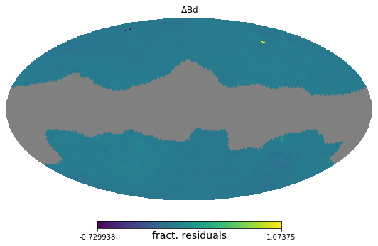

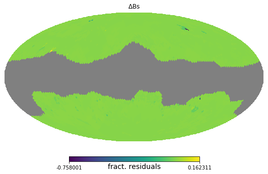

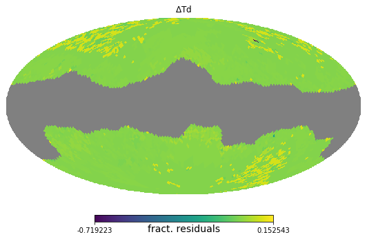

```python
pl.figure(figsize=(15,8))
diff = (result.x[1][idpatches] - bdpysm )/bdpysm
diff[~Galmask]=hp.UNSEEN
hp.mollview(diff
            ,sub=121, title =r'$\Delta $Bd'  , unit='fract. residuals'  )
pl.figure(figsize=(15,8))

diff = (result.x[0][idpatches] -(-3) )/(-3)
diff[~Galmask]=hp.UNSEEN
hp.mollview(diff
            ,sub=121, title =r'$\Delta $Bs'  , unit='fract. residuals'  )
pl.figure(figsize=(15,8))

diff = (result.x[2][idpatches] -(20) )/(20)
diff[~Galmask]=hp.UNSEEN
hp.mollview(diff
            ,sub=121, title =r'$\Delta $Td'  , unit='fract. residuals'  )
```

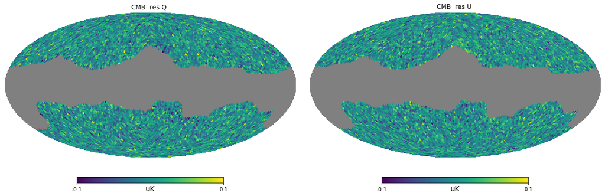

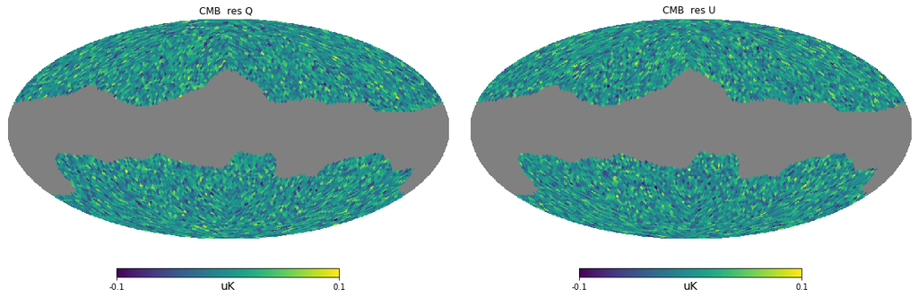

```python
pl.figure(figsize=(16,10 ))

hp.mollview(result.s[0,0] , title='CMB  res Q ', sub=(121), min=-0.1,max=0.1, unit='uK')
hp.mollview(result.s[0,1] , title='CMB  res U ', sub=(122), min=-0.1,max=0.1, unit='uK')


_=pl.figure(figsize=(16,10 ))
hp.mollview(resultconst.s[0,0] , title='CMB  res Q ', sub=(121), min=-0.1,max=0.1, unit='uK')
hp.mollview(resultconst.s[0,1] , title='CMB  res U ', sub=(122), min=-0.1,max=0.1, unit='uK')
```

```python
m = pl.zeros_like (freq_maps[0])
mconst = pl.zeros_like (freq_maps[0] )
for i in range(2):
    m[i+1,:] = result.s[0,i]
    mconst[i+1,:] = resultconst .s[0,i]
clconst = hp.anafast(   mconst    ,lmax=3*nside  )
cl = hp.anafast(m   ,lmax=3*nside  )
ell=pl.arange(  cl.shape[1]   )
```

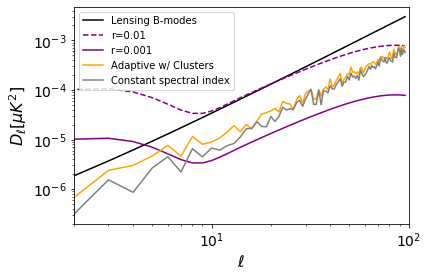

```python
clr = pl.loadtxt('/Users/peppe/work/satellite_sims/power_spectra/Class_planck2015_r0_cl_lensed.dat')
clr1 = pl.loadtxt('/Users/peppe/work/satellite_sims/power_spectra/Class_planck2015_r1_cl_unlensed.dat')
pl.loglog(ell, clr[ :ell.shape[0],3]*ell*( ell +1)/2./pl.pi   ,'k',label='Lensing B-modes'  )
pl.loglog(ell, clr1[ :ell.shape[0],3]*ell*( ell +1)/2./pl.pi /100.  ,'--',color='purple', label='r=0.01'  )
pl.loglog(ell, clr1[ :ell.shape[0],3]*ell*( ell +1)/2./pl.pi /1000.  ,color='purple',label='r=0.001 '  )
pl.loglog(ell, ell*( ell +1)/2./pl.pi* cl[2, :], color='orange', label = 'Adaptive w/ Clusters')

pl.loglog(ell, ell*( ell +1)/2./pl.pi* clconst[2, :], color='grey',  label='Constant spectral index')
pl.xlim(2, 100)
pl.ylabel(r'$D_{\ell}  [ \mu K^2 ]$', fontsize=16)
pl.xlabel(r'$ {\ell}   $', fontsize=16)
pl.yticks(fontsize=14)
pl.xticks(fontsize=14)

pl.legend()
#pl.ylim(1e-7, 1e-2)
```